# Team 1 - Lab 1

Dynamic Factor Analysis (DFA) - Common trends in plankton data

Mary, Emma, Anna

# Data

## Load the data

```r
## load MARSS for data and analyses
library(MARSS)

## load the raw data (there are 3 datasets contained here)
data(lakeWAplankton, package = "MARSS")

## we want `lakeWAplanktonTrans`, which has been transformed
## so the 0's are replaced with NA's and the data z-scored
all_dat <- lakeWAplanktonTrans
```

#Now we want to visualze what taxa and covariates are included in the data, and how many months are convered.

```r
# View column names
colnames(all_dat)
```

```
##  [1] "Year"                    "Month"
##  [3] "Temp"                    "TP"
##  [5] "pH"                      "Cryptomonas"
##  [7] "Diatoms"                 "Greens"
##  [9] "Bluegreens"              "Unicells"
## [11] "Other.algae"             "Conochilus"
## [13] "Cyclops"                 "Daphnia"
## [15] "Diaptomus"               "Epischura"
## [17] "Leptodora"               "Neomysis"
## [19] "Non.daphnid.cladocerans" "Non.colonial.rotifers"
```

```r
# See number of months and variables
dim(all_dat)
```

```
## [1] 396  20
```

#To visualize data across time, we can make a heatmap of missing vs present values to help identify which variables have good coverage and what time windows have fewer gaps.

```r
#Make a heatmap of missing vs. present values:
```

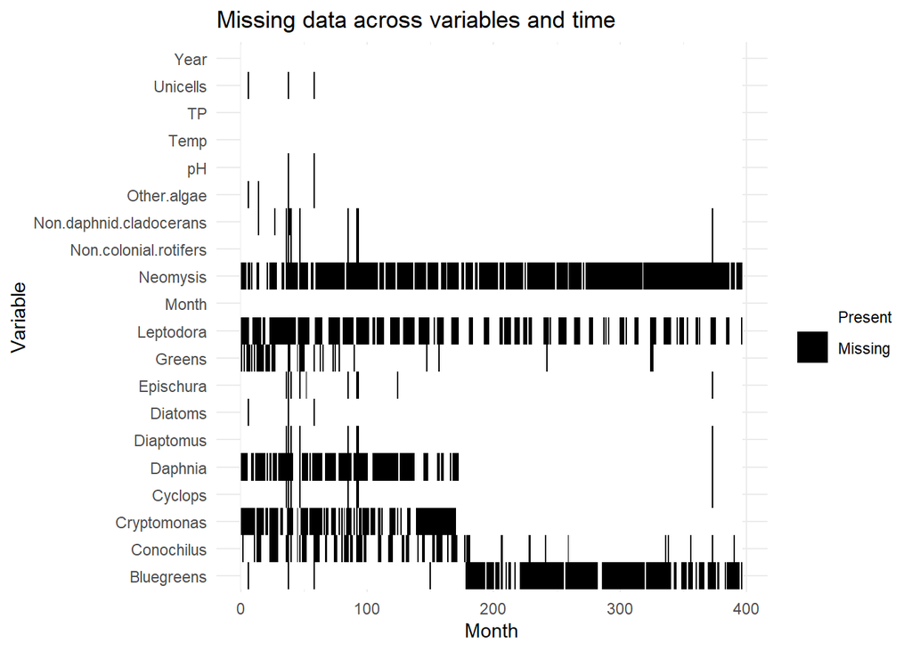

```r
library(tidyr)
library(ggplot2)

# Turn matrix into long format
dat_long <- as.data.frame(all_dat) %>%
  mutate(month = 1:n()) %>%
  pivot_longer(-month, names_to = "variable", values_to = "value") %>%
  mutate(missing = is.na(value))

# Plot missing data
ggplot(dat_long, aes(x = month, y = variable, fill = missing)) +
  geom_tile() +
  scale_fill_manual(values = c("white", "black"), labels = c("Present", "Missing")) +
  labs(title = "Missing data across variables and time",
       x = "Month", y = "Variable", fill = "") +
  theme_minimal()
```

## Wrangle the data

Based on the available data, we decided to choose these 6 taxa groups for analysis: 1. Daphnia: Key grazer, central to lake food webs 2. Cyclops: A common zooplantkton, some predation 3. Diaptomus: Another dominant grazer 4. Diatoms: Major edible phytoplankton group 5. Cryptomonus: Small, fast-growing plankton 6. Epischura: Predatory zooplankton These 6 taxa were chosen due to their range of ecological roles within the Lake Washington food web, including common zooplankton grazers, major phytoplankton groups, and one large predatory zooplankton. This mix allows us to capture both bottom-up and top-down ecological dynamics, and all taxa showed sufficient data coverage over a shared time window, making them suitable for Dynamic Factor Analysis.

Now we want to clarify which months have continuous data.

```r
# Define the selected 6 taxa
selected_taxa <- c("Daphnia", "Cyclops", "Diaptomus", "Diatoms", "Cryptomonas", "Epischura")

# Subset the dataset to just those columns
taxa_data <- all_dat[, selected_taxa]

# Count how many NAs are in each row (each month)
row_na_count <- apply(taxa_data, 1, function(x) sum(is.na(x)))

# Identify which months have no missing values across any of the 6 taxa
complete_months <- which(row_na_count == 0)

# Use rle() to find runs of consecutive complete months
rle_blocks <- rle(diff(complete_months) == 1)
ends <- cumsum(rle_blocks$lengths)
starts <- c(1, head(ends, -1) + 1)

# Build a table of those blocks
blocks <- data.frame(
  start_index = complete_months[starts],
  end_index = complete_months[ends],
  duration = complete_months[ends] - complete_months[starts] + 1
)

# Keep only blocks at least 60 months long (5 years)
long_blocks <- blocks[blocks$duration >= 60, ]

# Show the blocks
print(long_blocks)
```

```
##   start_index end_index duration
## 8         173       371      199
```

```r
# Step 1: Define the six selected taxa
selected_taxa <- c("Daphnia", "Cyclops", "Diaptomus", "Diatoms", "Cryptomonas", "Epischura")

# Step 2: Subset the full dataset to the selected taxa and time window (months 173 to 371)
raw_subset <- all_dat[173:371, selected_taxa]

# Step 3: Remove any months that contain missing data for these taxa
clean_subset <- raw_subset[complete.cases(raw_subset), ]

# Step 4: Transpose the data so that taxa = rows, time = columns (as required by MARSS)
dfa_data <- t(as.matrix(clean_subset))

# Step 5: Check structure and confirm no missing values
dim(dfa_data)      # Should be 6 rows x ~190-199 columns
```

```
## [1]   6 199
```

```r
anyNA(dfa_data)    # Should be FALSE
```

```
## [1] FALSE
```

After subsetting and cleaning the data to remove missing values, we prepared a z-scored matrix of six ecologically relevant plankton taxa from Lake Washington with complete monthly records over 199 months. We now fit a dynamic factor analysis (DFA) model using the MARSS package to identify common trends in the time series. DFA is useful for uncovering latent (hidden) structures that explain shared temporal variability across multiple time series.

We begin by fitting a simple model with a single common trend and a shared, correlated error structure across taxa. This allows us to assess whether a single latent process can capture major patterns across the six plankton groups.

```r
# Step 1: Create Z matrix for 1-trend model
Z <- matrix(list(), nrow = 6, ncol = 1)
rownames(Z) <- rownames(dfa_data)
for(i in 1:6) {
  Z[i, 1] <- paste0("z", i)
}

# Step 2: Define DFA model structure
model.list <- list(
  Z = Z,
  R = "diagonal and unequal",
  B = "identity",
  U = "zero",
  Q = "identity",
  x0 = "zero",
  V0 = "zero",
  A = "zero"
)

# Step 3: Fit the model
fit_1trend <- MARSS(dfa_data, model = model.list, control = list(maxit = 5000))
```

```
## Warning! Abstol convergence only. Maxit (=5000) reached before log-log convergence.
##
## MARSS fit is
## Estimation method: kem
## Convergence test: conv.test.slope.tol = 0.5, abstol = 0.001
## WARNING: Abstol convergence only no log-log convergence.
##  maxit (=5000) reached before log-log convergence.
##  The likelihood and params might not be at the ML values.
##  Try setting control$maxit higher.
## Log-likelihood: -1496.557
## AIC: 3017.114   AICc: 3017.378
##
##                             Estimate
## Z.z1                        0.308248
## Z.z2                        0.883175
## Z.z3                        0.311567
## Z.z4                        0.293508
## Z.z5                        0.257293
## Z.z6                        0.176728
## R.(Daphnia,Daphnia)         0.653515
## R.(Cyclops,Cyclops)         0.000811
## R.(Diaptomus,Diaptomus)     0.942307
## R.(Diatoms,Diatoms)         0.697944
## R.(Cryptomonas,Cryptomonas) 0.473002
## R.(Epischura,Epischura)     0.862732
## Initial states (x0) defined at t=0
##
## Standard errors have not been calculated.
## Use MARSSparamCIs to compute CIs and bias estimates.
##
## Convergence warnings
##  Warning: the  R.(Cyclops,Cyclops)  parameter value has not converged.
##  Type MARSSinfo("convergence") for more info on this warning.
```

```r
# Step 4: View results
summary(fit_1trend)
```

```
##
## m: 1 state process(es) named X1
## n: 6 observation time series named Daphnia Cyclops Diaptomus Diatoms Cryptomonas Epischura
##
##                           term     estimate
## 1                         Z.z1 0.3082475660
## 2                         Z.z2 0.8831751738
## 3                         Z.z3 0.3115668236
## 4                         Z.z4 0.2935083519
## 5                         Z.z5 0.2572934790
## 6                         Z.z6 0.1767280228
## 7          R.(Daphnia,Daphnia) 0.6535145817
## 8          R.(Cyclops,Cyclops) 0.0008111158
## 9      R.(Diaptomus,Diaptomus) 0.9423072502
## 10         R.(Diatoms,Diatoms) 0.6979443135
## 11 R.(Cryptomonas,Cryptomonas) 0.4730023935
## 12     R.(Epischura,Epischura) 0.8627320108
```

Plot the trend:

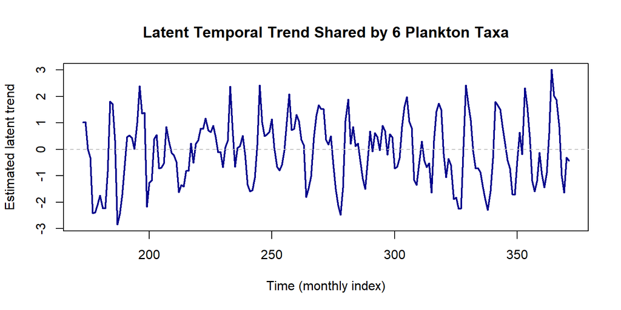

```r
# Step 1: Extract the estimated trend (state variable X) from the model
dfa_trend <- fit_1trend$states[1, ]  # Since we only have 1 trend

# Step 2: Create a time variable that matches the 199-month window
# You originally subset rows 173:371, so the corresponding months are:
time_index <- 173:371

# Step 3: Plot the trend
plot(time_index, dfa_trend, type = "l",
     lwd = 2, col = "darkblue",
     xlab = "Time (monthly index)",
     ylab = "Estimated latent trend",
     main = "Latent Temporal Trend Shared by 6 Plankton Taxa")
abline(h = 0, lty = 2, col = "gray")
```

This graph represents a dynamic factor analysis (DFA) model with one latent trend (m = 1) and no covariates using six selected plankton taxa from Lake Washington. This model looked for a shared temporal pattern across the taxa and estimated how strongly each group followed that pattern. We found that Cyclops was the most closely aligned with the trend, while Epischura showed the weakest association. The model ran successfully, although we got a warning that it didn’t fully converge, which suggests there’s still room to improve the fit.

In the first model, you assumed that one shared trend explained the dynamics of all 6 taxa. But in ecological systems, it’s possible that multiple processes or groups of taxa are responding to different underlying patterns.So now we’ll fit a 2-trend DFA model (m = 2), which tries to identify two separate but simultaneous temporal trends in the data. This lets the model capture more complex patterns,reveal if some taxa group together while others behave differently,potentially lower the AIC (i.e., improve model fit).

We’ll keep the observation error structure the same (“diagonal and unequal”) and still avoid covariates for now — just adding a second trend.

```r
# Step 1: Create Z matrix for 2-trend model
Z2 <- matrix(list(), nrow = 6, ncol = 2)
rownames(Z2) <- rownames(dfa_data)
for(i in 1:6) {
  Z2[i, 1] <- paste0("z", (2*i - 1))
  Z2[i, 2] <- paste0("z", (2*i))
}

# Step 2: Define DFA model structure with 2 trends
model.list2 <- list(
  Z = Z2,
  R = "diagonal and unequal",
  B = "identity",
  U = "zero",
  Q = "identity",   # or "equalvarcov" if you want trends to covary
  x0 = "zero",
  V0 = "zero",
  A = "zero"
)

# Step 3: Fit the model
fit_2trend <- MARSS(dfa_data, model = model.list2, control = list(maxit = 5000))
```

```
## Warning! Abstol convergence only. Maxit (=5000) reached before log-log convergence.
##
## MARSS fit is
## Estimation method: kem
## Convergence test: conv.test.slope.tol = 0.5, abstol = 0.001
## WARNING: Abstol convergence only no log-log convergence.
##  maxit (=5000) reached before log-log convergence.
##  The likelihood and params might not be at the ML values.
##  Try setting control$maxit higher.
## Log-likelihood: -1439.405
## AIC: 2914.811   AICc: 2915.393
##
##                             Estimate
## Z.z1                        0.207901
## Z.z3                        0.626570
## Z.z5                        0.237741
## Z.z7                        0.198458
## Z.z9                        0.156101
## Z.z11                       0.132096
## Z.z2                        0.226003
## Z.z4                        0.622298
## Z.z6                        0.205970
## Z.z8                        0.214873
## Z.z10                       0.203029
## Z.z12                       0.119066
## R.(Daphnia,Daphnia)         0.624197
## R.(Cyclops,Cyclops)         0.000904
## R.(Diaptomus,Diaptomus)     0.872140
## R.(Diatoms,Diatoms)         0.673601
## R.(Cryptomonas,Cryptomonas) 0.295479
## R.(Epischura,Epischura)     0.851371
## Initial states (x0) defined at t=0
##
## Standard errors have not been calculated.
## Use MARSSparamCIs to compute CIs and bias estimates.
##
## Convergence warnings
##  Warning: the  R.(Cyclops,Cyclops)  parameter value has not converged.
##  Type MARSSinfo("convergence") for more info on this warning.
```

```r
# Step 4: View results
summary(fit_2trend)
```

```
##
## m: 2 state process(es) named X1 X2
## n: 6 observation time series named Daphnia Cyclops Diaptomus Diatoms Cryptomonas Epischura
##
##                           term     estimate
## 1                         Z.z1 0.2079007258
## 2                         Z.z3 0.6265696394
## 3                         Z.z5 0.2377412678
## 4                         Z.z7 0.1984580964
## 5                         Z.z9 0.1561011499
## 6                        Z.z11 0.1320961094
## 7                         Z.z2 0.2260033086
## 8                         Z.z4 0.6222982717
## 9                         Z.z6 0.2059699157
## 10                        Z.z8 0.2148726855
## 11                       Z.z10 0.2030289710
## 12                       Z.z12 0.1190656745
## 13         R.(Daphnia,Daphnia) 0.6241970334
## 14         R.(Cyclops,Cyclops) 0.0009038478
## 15     R.(Diaptomus,Diaptomus) 0.8721403562
## 16         R.(Diatoms,Diatoms) 0.6736006874
## 17 R.(Cryptomonas,Cryptomonas) 0.2954794257
## 18     R.(Epischura,Epischura) 0.8513713323
```

Plot latent trends and loading:

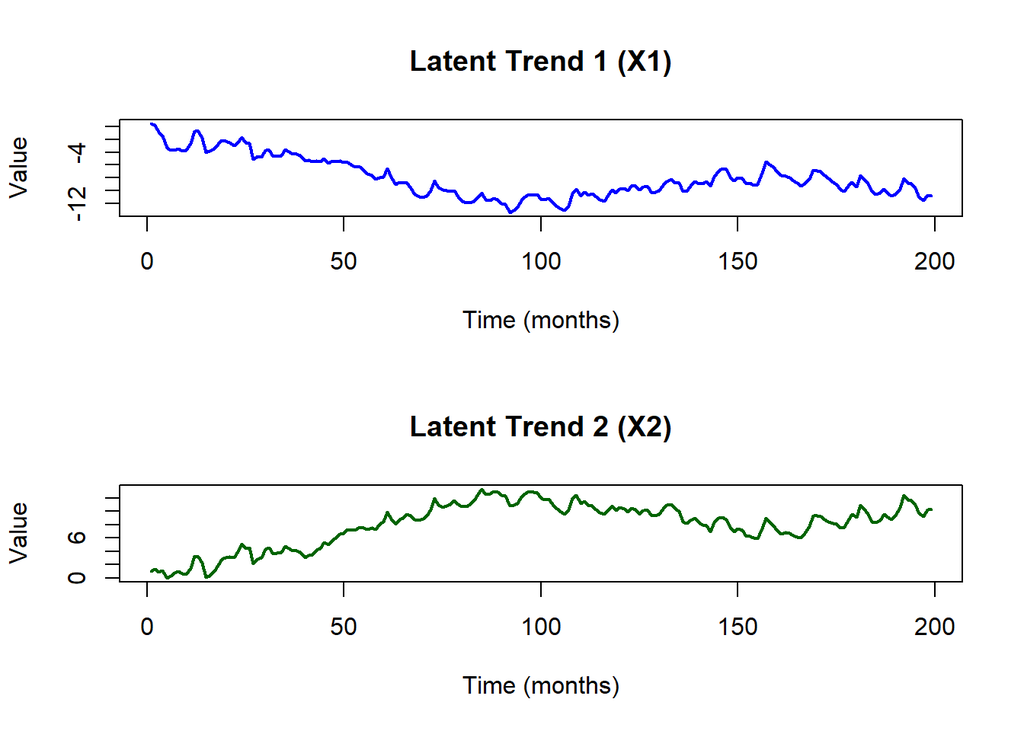

```r
# Extract the latent trends from the fitted model
trend_ts <- fit_2trend$states

# Plot each trend separately
par(mfrow = c(2, 1))  # 2 rows, 1 column layout
plot(trend_ts[1, ], type = "l", col = "blue", lwd = 2,
     main = "Latent Trend 1 (X1)", ylab = "Value", xlab = "Time (months)")
plot(trend_ts[2, ], type = "l", col = "darkgreen", lwd = 2,
     main = "Latent Trend 2 (X2)", ylab = "Value", xlab = "Time (months)")
```

[figure not shown]

```r
# Reset layout
par(mfrow = c(1, 1))

# Plot the Z matrix loadings
Z_est <- coef(fit_2trend, type = "matrix")$Z
barplot(Z_est, beside = TRUE, col = c("blue", "darkgreen"),
        legend = c("Trend 1", "Trend 2"),
        main = "Taxon Loadings on Each Trend",
        ylab = "Loading Strength")
```

After fitting the 2-trend DFA model, we examined the resulting latent trends and taxon loadings to understand the shared temporal patterns in our selected plankton groups. Trend 1 (X1) shows a long-term decline across the time series, which might reflect gradual environmental changes like nutrient limitation or warming. Trend 2 (X2) shows a more dynamic pattern with a steady rise and mild decline, possibly linked to shorter-term ecological or climatic variability.

TO reinforce model comparisons, we will now try a 3-trend model:

```r
# Step 1: Create Z matrix for 3-trend model
Z3 <- matrix(list(), nrow = 6, ncol = 3)
rownames(Z3) <- rownames(dfa_data)
for(i in 1:6) {
  for(j in 1:3) {
    Z3[i, j] <- paste0("z", i, j)
  }
}

# Step 2: Define the model list
model.list3 <- list(
  Z = Z3,
  R = "diagonal and unequal",
  B = "identity",
  U = "zero",
  Q = "identity",
  x0 = "zero",
  V0 = "zero",
  A = "zero"
)

# Step 3: Fit the model (set higher maxit just in case)
fit_3trend <- MARSS(dfa_data, model = model.list3, control = list(maxit = 5000))
```

```
## Warning! Abstol convergence only. Maxit (=5000) reached before log-log convergence.
##
## MARSS fit is
## Estimation method: kem
## Convergence test: conv.test.slope.tol = 0.5, abstol = 0.001
## WARNING: Abstol convergence only no log-log convergence.
##  maxit (=5000) reached before log-log convergence.
##  The likelihood and params might not be at the ML values.
##  Try setting control$maxit higher.
## Log-likelihood: -1337.318
## AIC: 2722.636   AICc: 2723.662
##
##                              Estimate
## Z.z11                        0.648186
## Z.z21                        0.464149
## Z.z31                        0.032369
## Z.z41                       -0.008534
## Z.z51                        0.056110
## Z.z61                        0.277714
## Z.z12                        0.028830
## Z.z22                        0.484144
## Z.z32                        0.220917
## Z.z42                        0.241358
## Z.z52                        0.206546
## Z.z62                        0.036145
## Z.z13                       -0.044661
## Z.z23                        0.490001
## Z.z33                        0.273350
## Z.z43                        0.243657
## Z.z53                        0.166395
## Z.z63                        0.030683
## R.(Daphnia,Daphnia)          0.000335
## R.(Cyclops,Cyclops)          0.064650
## R.(Diaptomus,Diaptomus)      0.789367
## R.(Diatoms,Diatoms)          0.579790
## R.(Cryptomonas,Cryptomonas)  0.265609
## R.(Epischura,Epischura)      0.762631
## Initial states (x0) defined at t=0
##
## Standard errors have not been calculated.
## Use MARSSparamCIs to compute CIs and bias estimates.
##
## Convergence warnings
##  Warning: the  R.(Daphnia,Daphnia)  parameter value has not converged.
##  Type MARSSinfo("convergence") for more info on this warning.
```

```r
# Step 4: View results
summary(fit_3trend)
```

```
##
## m: 3 state process(es) named X1 X2 X3
## n: 6 observation time series named Daphnia Cyclops Diaptomus Diatoms Cryptomonas Epischura
##
##                           term      estimate
## 1                        Z.z11  0.6481861349
## 2                        Z.z21  0.4641487497
## 3                        Z.z31  0.0323690946
## 4                        Z.z41 -0.0085340396
## 5                        Z.z51  0.0561102656
## 6                        Z.z61  0.2777138891
## 7                        Z.z12  0.0288300291
## 8                        Z.z22  0.4841436374
## 9                        Z.z32  0.2209172526
## 10                       Z.z42  0.2413581409
## 11                       Z.z52  0.2065462766
## 12                       Z.z62  0.0361454718
## 13                       Z.z13 -0.0446608688
## 14                       Z.z23  0.4900005722
## 15                       Z.z33  0.2733500413
## 16                       Z.z43  0.2436570963
## 17                       Z.z53  0.1663949173
## 18                       Z.z63  0.0306833288
## 19         R.(Daphnia,Daphnia)  0.0003347958
## 20         R.(Cyclops,Cyclops)  0.0646504558
## 21     R.(Diaptomus,Diaptomus)  0.7893672984
## 22         R.(Diatoms,Diatoms)  0.5797899806
## 23 R.(Cryptomonas,Cryptomonas)  0.2656089105
## 24     R.(Epischura,Epischura)  0.7626305282
```

We also fit a 3-trend DFA model to explore whether a more complex structure would better explain variability in the plankton time series. While the model did not fully converge (abstol-only convergence), the AICc value was notably lower than the 1- and 2-trend models (AICc = 2723.66), suggesting the additional trend components helped improve model fit. We acknowledge convergence limitations but proceed with comparing this model to others for exploratory purposes.

Plot the 3-trend model:

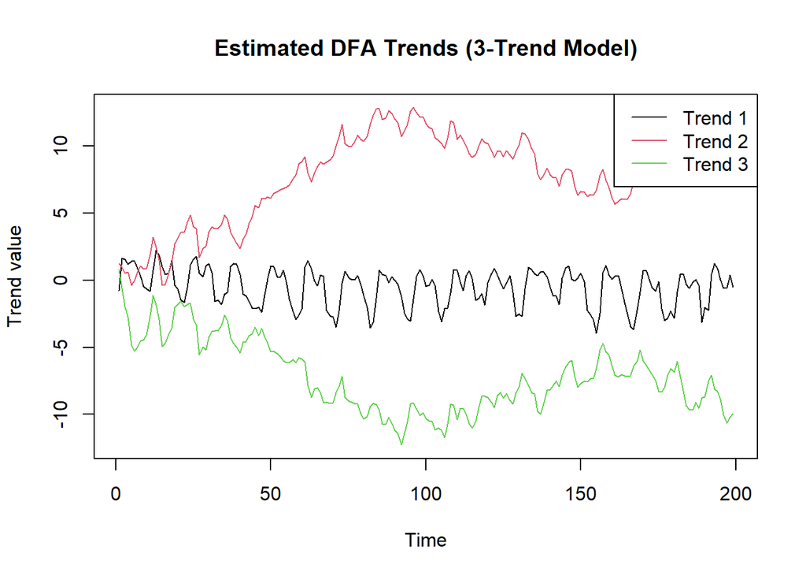

```r
# Step 1: Extract the estimated trends (states)
states_3trend <- fit_3trend$states

# Step 2: Plot the trends over time
ts.plot(t(states_3trend), col = 1:3, lty = 1, xlab = "Time", ylab = "Trend value", main = "Estimated DFA Trends (3-Trend Model)")
legend("topright", legend = paste("Trend", 1:3), col = 1:3, lty = 1)
```

[figure not shown]

```r
# Step 3: Plot the loadings (Z matrix values)
Z_estimates <- coef(fit_3trend, type = "matrix")$Z
barplot(Z_estimates, beside = TRUE, col = 1:3,
        legend.text = paste("Trend", 1:3),
        args.legend = list(x = "topright", bty = "n"),
        main = "Factor Loadings (Z matrix)", ylab = "Loading strength", las = 2)
```

After fitting DFA models with 1, 2, and 3 latent trends, we compared their performance using AIC and AICc values. The 3-trend model had the lowest AICc, suggesting it provides the best fit to the observed plankton time series. Each trend represents an underlying pattern in community dynamics over time, and the factor loadings reveal how each taxon aligns with these trends. While all models reached only abstol convergence, the consistent improvement in AICc across models supports the added complexity of the 3-trend solution.

##Error Structure Impacts

```r
# Step 1: Use same Z matrix and model list as before, but change R structure
Z_equal <- matrix(list(), nrow = 6, ncol = 2)  # assuming you're comparing to your 2-trend model
rownames(Z_equal) <- rownames(dfa_data)
for(i in 1:6){
  Z_equal[i,1] <- paste0("z", i)
  Z_equal[i,2] <- paste0("z", i+6)
}

# Step 2: Define new model with equal error variance
model.equalvar <- list(
  Z = Z_equal,
  R = "diagonal and equal",
  B = "identity",
  U = "zero",
  Q = "identity",
  x0 = "zero",
  V0 = "zero",
  A = "zero"
)

# Step 3: Fit the model
fit_equalvar <- MARSS(dfa_data, model = model.equalvar, control = list(maxit = 5000))
```

```
## Success! abstol and log-log tests passed at 114 iterations.
## Alert: conv.test.slope.tol is 0.5.
## Test with smaller values (<0.1) to ensure convergence.
##
## MARSS fit is
## Estimation method: kem
## Convergence test: conv.test.slope.tol = 0.5, abstol = 0.001
## Estimation converged in 114 iterations.
## Log-likelihood: -1493.831
## AIC: 3013.662   AICc: 3013.971
##
##        Estimate
## Z.z1      0.156
## Z.z2      0.446
## Z.z3      0.333
## Z.z4      0.164
## Z.z5      0.118
## Z.z6      0.215
## Z.z7      0.200
## Z.z8      0.447
## Z.z9      0.262
## Z.z10     0.198
## Z.z11     0.198
## Z.z12     0.190
## R.diag    0.581
## Initial states (x0) defined at t=0
##
## Standard errors have not been calculated.
## Use MARSSparamCIs to compute CIs and bias estimates.
```

```r
# Step 4: View results
summary(fit_equalvar)
```

```
##
## m: 2 state process(es) named X1 X2
## n: 6 observation time series named Daphnia Cyclops Diaptomus Diatoms Cryptomonas Epischura
##
##      term  estimate
## 1    Z.z1 0.1558594
## 2    Z.z2 0.4462454
## 3    Z.z3 0.3332670
## 4    Z.z4 0.1636088
## 5    Z.z5 0.1178907
## 6    Z.z6 0.2153735
## 7    Z.z7 0.1997640
## 8    Z.z8 0.4468848
## 9    Z.z9 0.2616941
## 10  Z.z10 0.1976120
## 11  Z.z11 0.1977007
## 12  Z.z12 0.1895619
## 13 R.diag 0.5805292
```

```r
# Compare AICc values of equal vs unequal variance
cbind(
  model = c("2-trend unequal R", "2-trend equal R"),
  AICc = c(fit_2trend$AICc, fit_equalvar$AICc)
)
```

```
##      model               AICc
## [1,] "2-trend unequal R" "2915.39306563907"
## [2,] "2-trend equal R"   "3013.97062672903"
```

```r
# Compare AICc values across all fitted models
aic_table <- data.frame(
  Model = c("1-Trend", "2-Trend", "3-Trend", "2-Trend Equal Error"),
  AICc = c(
    fit_1trend$AICc,
    fit_2trend$AICc,
    fit_3trend$AICc,
    fit_equalvar$AICc
  )
)

print(aic_table)
```

```
##                 Model     AICc
## 1             1-Trend 3017.378
## 2             2-Trend 2915.393
## 3             3-Trend 2723.662
## 4 2-Trend Equal Error 3013.971
```